# Final_Proj

Khoa Nguyen

3/9/2021

```r
if ( !dir.exists( here::here("Final_project", "data_raw") ) ) {
  dir.create( here::here("Final_project", "data_raw", "output", ".R"), recursive = TRUE )
}
```

# Divorce rate trend and Marriage Rate Trend Comparison.

## Research Questions.

> Is the differences between the marriage trend and dicorve trend throughout the years significant enough for us to reconsider what is the criteria for a committed marriage? This is also a follow-up to the original study.

```r
url <- "https://raw.githubusercontent.com/fivethirtyeight/data/master/marriage/divorce.csv"
bothsexes <- "https://raw.githubusercontent.com/fivethirtyeight/data/master/marriage/both_sexes.csv"
men <- "https://raw.githubusercontent.com/fivethirtyeight/data/master/marriage/men.csv"
women <-  "https://raw.githubusercontent.com/fivethirtyeight/data/master/marriage/women.csv"
```

```r
Major_data <- read.csv(url,
                       na = c("NA", " ", "-999"))
both_gender <-  read.csv(bothsexes,
                       na = c("NA", " ", "-999"))
men_data <-  read.csv(men,
                       na = c("NA", " ", "-999"))
women_data <-  read.csv(women,
                       na = c("NA", " ", "-999"))
```

```r
write.csv(Major_data,
          here::here("Final_project", "data_raw", "Major_data.csv"))
write.csv(both_gender,
          here::here("Final_project", "data_raw", "Both_gender.csv"))
write.csv(men_data,
          here::here("Final_project", "data_raw", "Men_data.csv"))
write.csv(women_data,
          here::here("Final_project", "data_raw", "Women_data.csv"))
```

```r
read.csv(
  here::here("Final_Project", "data_raw", "Major_data.csv"))
```

```
##    X.1  X year       date   all_3544    HS_3544    SC_3544   BAp_3544
## 1    1  1 1960 1960-01-01 0.03444454 0.03488887 0.03366938 0.02751277
## 2    2  2 1970 1970-01-01 0.04925600 0.04999984 0.04870549 0.04125945
## 3    3  3 1980 1980-01-01 0.10600503 0.10415128 0.11269947 0.09777208
## 4    4  4 1990 1990-01-01 0.15080495 0.15938095 0.16967005 0.11495533
## 5    5  5 2000 2000-01-01 0.15684099 0.17544616 0.17380324 0.10561772
## 6    6  6 2001 2001-01-01 0.15730639 0.17411604 0.17816906 0.10703886
## 7    7  7 2002 2002-01-01 0.15650825 0.17476931 0.17929419 0.10344219
## 8    8  8 2003 2003-01-01 0.15384351 0.17254483 0.17697536 0.10254990
## 9    9  9 2004 2004-01-01 0.15484096 0.17756455 0.17707955 0.10033665
## 10  10 10 2005 2005-01-01 0.15291994 0.17516353 0.17674265 0.09948066
## 11  11 11 2006 2006-01-01 0.16188986 0.18943673 0.18412098 0.10383550
## 12  12 12 2007 2007-01-01 0.16046887 0.18721641 0.18496086 0.10392942
## 13  13 13 2008 2008-01-01 0.16115876 0.18837663 0.18944998 0.10201919
## 14  14 14 2009 2009-01-01 0.16049309 0.18698758 0.19013626 0.10194261
```

[output cut: 39 more lines]

```r
read.csv(
  here::here("Final_Project", "data_raw", "Both_gender.csv"))
```

```
##    X.1  X year       date  all_2534   HS_2534   SC_2534  BAp_2534  BAo_2534
## 1    1  1 1960 1960-01-01 0.1233145 0.1095332 0.1522818 0.2389952 0.2389952
## 2    2  2 1970 1970-01-01 0.1269715 0.1094000 0.1495096 0.2187031 0.2187031
## 3    3  3 1980 1980-01-01 0.1991767 0.1617313 0.2236916 0.2881646 0.2881646
## 4    4  4 1990 1990-01-01 0.2968306 0.2777491 0.2780912 0.3612968 0.3656655
## 5    5  5 2000 2000-01-01 0.3450087 0.3316545 0.3249205 0.3874906 0.3939579
## 6    6  6 2001 2001-01-01 0.3527767 0.3446069 0.3341101 0.3835686 0.3925148
## 7    7  7 2002 2002-01-01 0.3535249 0.3490367 0.3361595 0.3774328 0.3870840
## 8    8  8 2003 2003-01-01 0.3620345 0.3581877 0.3418930 0.3873806 0.4000039
## 9    9  9 2004 2004-01-01 0.3673247 0.3708102 0.3450748 0.3847357 0.3976124
## 10  10 10 2005 2005-01-01 0.3793451 0.3870680 0.3596663 0.3886096 0.4029116
## 11  11 11 2006 2006-01-01 0.4147656 0.4312162 0.3912177 0.4147960 0.4298668
## 12  12 12 2007 2007-01-01 0.4269222 0.4441386 0.4084929 0.4209586 0.4389750
## 13  13 13 2008 2008-01-01 0.4394414 0.4599162 0.4235094 0.4297510 0.4473568
## 14  14 14 2009 2009-01-01 0.4625638 0.4845018 0.4469940 0.4518141 0.4743768
```

[output cut: 219 more lines]

```r
read.csv(
  here::here("Final_Project", "data_raw", "Men_data.csv"))
```

```
##    X.1  X year       date  all_2534   HS_2534   SC_2534  BAp_2534  BAo_2534
## 1    1  1 1960 1960-01-01 0.1624552 0.1500654 0.1844804 0.2247803 0.2247803
## 2    2  2 1970 1970-01-01 0.1554093 0.1412231 0.1723210 0.1990768 0.1990768
## 3    3  3 1980 1980-01-01 0.2373002 0.2081500 0.2564393 0.2834162 0.2834162
## 4    4  4 1990 1990-01-01 0.3491950 0.3394680 0.3329204 0.3902470 0.4033273
## 5    5  5 2000 2000-01-01 0.3919130 0.3797128 0.3778607 0.4290485 0.4434001
## 6    6  6 2001 2001-01-01 0.3997402 0.3931643 0.3851544 0.4255137 0.4426400
## 7    7  7 2002 2002-01-01 0.3969647 0.3954700 0.3814238 0.4152810 0.4295553
## 8    8  8 2003 2003-01-01 0.4073297 0.4033001 0.3946632 0.4265825 0.4478791
## 9    9  9 2004 2004-01-01 0.4106667 0.4115010 0.3942030 0.4260731 0.4475950
## 10  10 10 2005 2005-01-01 0.4232072 0.4301459 0.4087442 0.4270559 0.4502465
## 11  11 11 2006 2006-01-01 0.4655376 0.4817844 0.4436976 0.4591193 0.4791522
## 12  12 12 2007 2007-01-01 0.4771489 0.4940523 0.4616199 0.4631180 0.4878777
## 13  13 13 2008 2008-01-01 0.4910558 0.5098585 0.4783502 0.4739166 0.5000644
## 14  14 14 2009 2009-01-01 0.5145486 0.5359545 0.5001706 0.4966576 0.5262635
```

[output cut: 309 more lines]

```r
read.csv(
  here::here("Final_Project", "data_raw", "Women_data.csv"))
```

```
##    X.1  X year       date   all_2534    HS_2534   SC_2534  BAp_2534  BAo_2534
## 1    1  1 1960 1960-01-01 0.08594174 0.07501998 0.1146281 0.2882222 0.2882222
## 2    2  2 1970 1970-01-01 0.09997836 0.08307902 0.1251594 0.2700100 0.2700100
## 3    3  3 1980 1980-01-01 0.16197333 0.12249418 0.1892959 0.2952480 0.2952480
## 4    4  4 1990 1990-01-01 0.24448143 0.21128474 0.2296344 0.3319387 0.3294701
## 5    5  5 2000 2000-01-01 0.29756106 0.27379411 0.2774183 0.3506060 0.3502802
## 6    6  6 2001 2001-01-01 0.30670747 0.28942418 0.2884819 0.3467877 0.3487494
## 7    7  7 2002 2002-01-01 0.31073909 0.29408223 0.2967044 0.3447053 0.3502065
## 8    8  8 2003 2003-01-01 0.31709338 0.30528912 0.2943780 0.3532717 0.3571160
## 9    9  9 2004 2004-01-01 0.32448209 0.32148668 0.3015154 0.3499114 0.3546175
## 10  10 10 2005 2005-01-01 0.33569178 0.33462916 0.3150642 0.3566786 0.3624953
## 11  11 11 2006 2006-01-01 0.36221284 0.36400704 0.3435716 0.3782479 0.3876603
## 12  12 12 2007 2007-01-01 0.37490322 0.37714490 0.3599842 0.3865649 0.3974012
## 13  13 13 2008 2008-01-01 0.38595258 0.39148037 0.3727014 0.3938719 0.4026639
## 14  14 14 2009 2009-01-01 0.40865243 0.41316592 0.3968364 0.4157115 0.4302428
```

[output cut: 309 more lines]

> Our main objective for this project is to perform a follow-up study to examine the trend of marriage across education level for both gender across time, along with measurint it against the divorce rate trend.

## Summarizing data and observing the marriage trend for Individuals with a High School Diploma or Less.

### Men Marriage Trend Data for individuals with only a high school diploma and less.

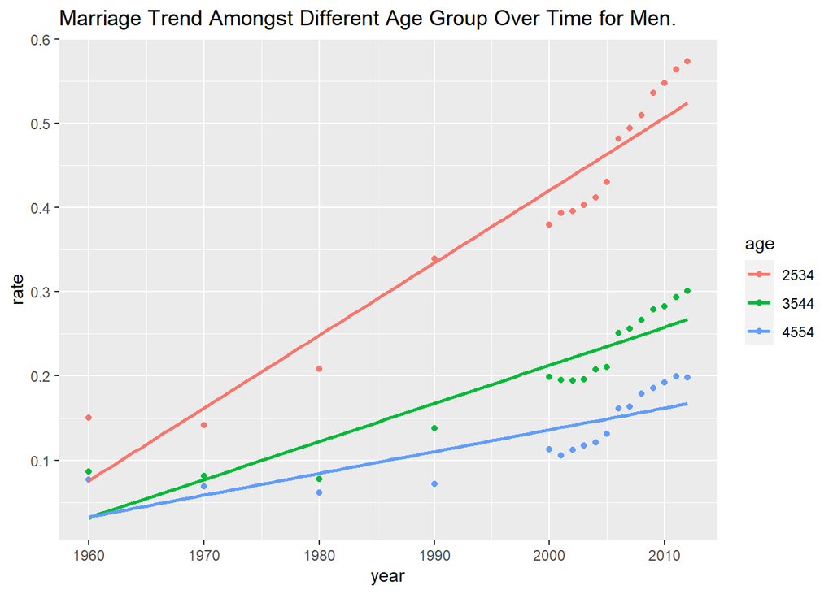

```r
m <- men_data %>%
  select(year, starts_with("HS_"))

m_long <- m %>% pivot_longer(
  cols = -year,
  names_sep = "_",
  names_to = c("edu", "age"),
  values_to = "rate"
)


m_plot <- m_long %>%
  ggplot(aes(x=year,y=rate, color = age)) +
  geom_point() +
  geom_smooth(method = "lm", se = FALSE) +
  labs(title = "Marriage Trend Amongst Different Age Group Over Time for Men.")

m_plot
```

### women Marriage Data for individuals with only a high school diploma and less.

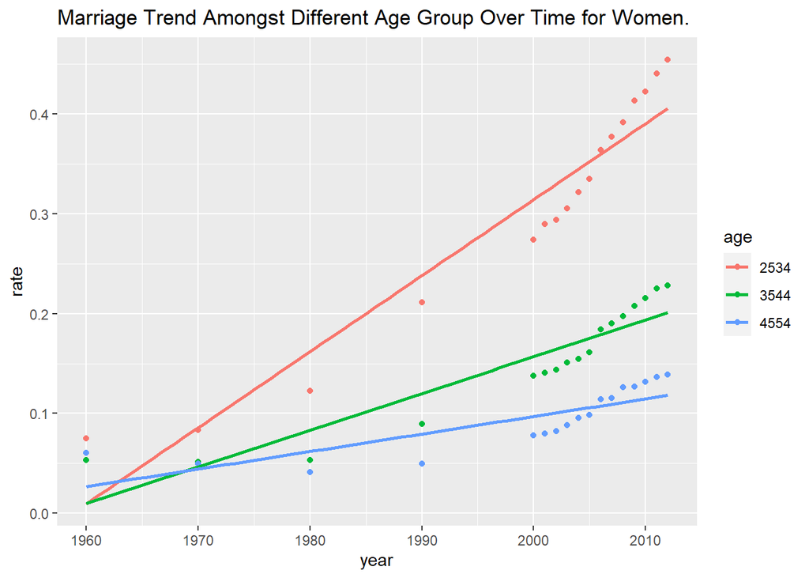

```r
w <- women_data %>%
  select(year, starts_with("HS_"))

w_long <- w %>% pivot_longer(
  cols = -year,
  names_sep = "_",
  names_to = c("edu", "age"),
  values_to = "rate"
)


w_plot <- w_long %>%
  ggplot(aes(x=year,y=rate, color = age)) +
  geom_point() +
  geom_smooth(method = "lm", se = FALSE) +
  labs(title = "Marriage Trend Amongst Different Age Group Over Time for Women.")

w_plot
```

## Comapring graphs of marriage trend for men and women who only have a high school diploma or less.

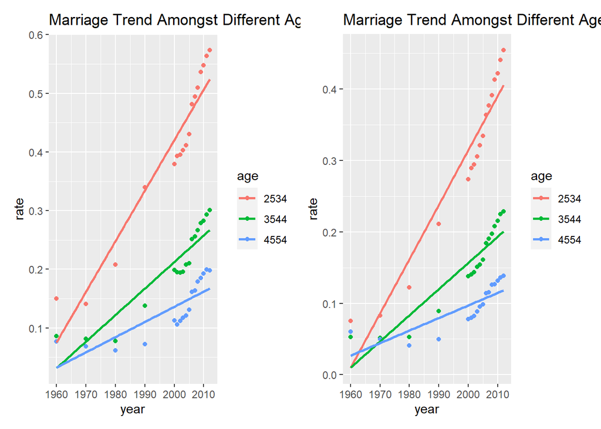

```r
combined_w_m_plot <- m_plot + w_plot
combined_w_m_plot
```

```r
ggsave(here::here("Final_project", "output", "figure",
                  "Marriage Trend Amongst Different Age Group Over Time for Men.svg"),
       m_plot,
       height = 6,
       width = 6)
ggsave(here::here("Final_project", "output", "figure",
                  "Marriage Trend Amongst Different Age Group Over Time for Women.svg"),
       w_plot,
       height = 6,
       width = 6)
ggsave(here::here("Final_project", "output", "figure",
                  "Marriage Trend Amongst Different Age Group Over Time for both gender.svg"),
       combined_w_m_plot,
       height = 6,
       width = 6)
```

> Now, we will look at the dataset for both gender and observe their marriage trend for individuals with only a high school diploma or less. To check our two previous datasets.

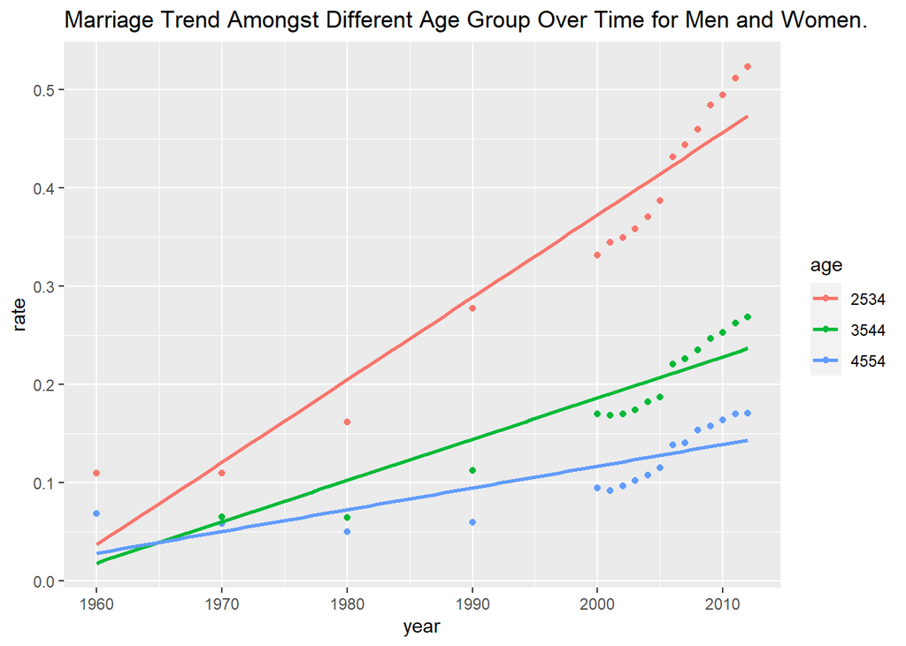

```r
bg <- both_gender %>%
  select(year, starts_with("HS_"))

bg_long <- bg %>% pivot_longer(
  cols = -year,
  names_sep = "_",
  names_to = c("edu", "age"),
  values_to = "rate"
)


bg_plot <- bg_long %>%
  ggplot(aes(x=year,y=rate, color = age)) +
  geom_point() +
  geom_smooth(method = "lm", se = FALSE) +
  labs(title = "Marriage Trend Amongst Different Age Group Over Time for Men and Women.")

bg_plot
```

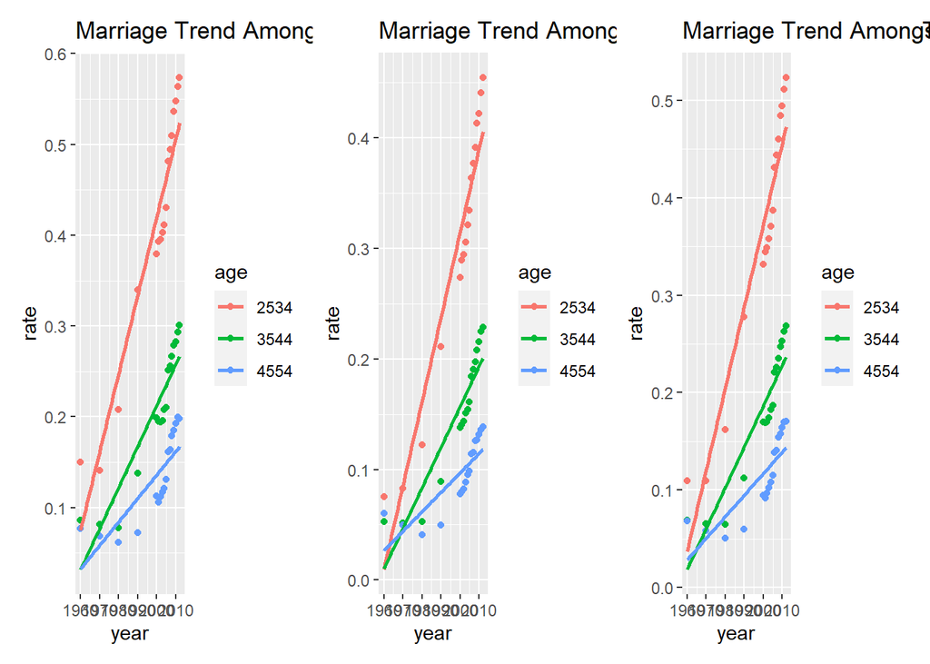

```r
main_compared_data <- m_plot + w_plot + bg_plot
main_compared_data
```

```r
ggsave(here::here("Final_project", "output", "figure",
                  "Comparison of Marriage Trend for Men and Women versus Combined.svg"),
       main_compared_data,
       height = 6,
       width = 6)
```

## Data summary of both gender for individuals with a high school diploma or less.

> First, I want to create a list of all of the age range of individuals holding a high school diploma or less.

```r
HS_all_age <- both_gender %>%
  select(c("year", "HS_2534", "HS_3544", "HS_4554"))
```

> Then I calculated the data.

```r
sum_for_both_gend <- HS_all_age %>%
  group_by(year) %>%
  summarise_all(funs(n(), mean, median))
sum_for_both_gend
```

```
## # A tibble: 17 x 10
##     year HS_2534_n HS_3544_n HS_4554_n HS_2534_mean HS_3544_mean HS_4554_mean
##  * <int>     <int>     <int>     <int>        <dbl>        <dbl>        <dbl>
##  1  1960         1         1         1        0.110       0.0686       0.0684
##  2  1970         1         1         1        0.109       0.0651       0.0583
##  3  1980         1         1         1        0.162       0.0643       0.0504
##  4  1990         1         1         1        0.278       0.112        0.0599
##  5  2000         1         1         1        0.332       0.170        0.0944
##  6  2001         1         1         1        0.345       0.169        0.0919
##  7  2002         1         1         1        0.349       0.170        0.0964
##  8  2003         1         1         1        0.358       0.174        0.102
##  9  2004         1         1         1        0.371       0.182        0.108
## 10  2005         1         1         1        0.387       0.187        0.115
## 11  2006         1         1         1        0.431       0.221        0.138
## 12  2007         1         1         1        0.444       0.226        0.140
## 13  2008         1         1         1        0.460       0.235        0.154
## 14  2009         1         1         1        0.485       0.247        0.158
## 15  2010         1         1         1        0.494       0.253        0.164
## 16  2011         1         1         1        0.512       0.263        0.170
## 17  2012         1         1         1        0.524       0.269        0.170
## # ... with 3 more variables: HS_2534_median <dbl>, HS_3544_median <dbl>,
## #   HS_4554_median <dbl>
```

```r
write.csv(sum_for_both_gend,
          here::here("Final_project", "output", "Sum_both_gend.csv"))
```

```r
Sum_both_gend_corr <- sum_for_both_gend %>%
  correlation::correlation(select = c("HS_2534_mean", "HS_3544_mean", "HS_4554_mean")) %>%
  summary()

both_gend_tab <- full_join(sum_for_both_gend, Sum_both_gend_corr)
both_gend_tab
```

```
## # A tibble: 19 x 11
##     year HS_2534_n HS_3544_n HS_4554_n HS_2534_mean HS_3544_mean HS_4554_mean
##    <int>     <int>     <int>     <int>        <dbl>        <dbl>        <dbl>
##  1  1960         1         1         1        0.110       0.0686       0.0684
##  2  1970         1         1         1        0.109       0.0651       0.0583
##  3  1980         1         1         1        0.162       0.0643       0.0504
##  4  1990         1         1         1        0.278       0.112        0.0599
##  5  2000         1         1         1        0.332       0.170        0.0944
##  6  2001         1         1         1        0.345       0.169        0.0919
##  7  2002         1         1         1        0.349       0.170        0.0964
##  8  2003         1         1         1        0.358       0.174        0.102
##  9  2004         1         1         1        0.371       0.182        0.108
## 10  2005         1         1         1        0.387       0.187        0.115
## 11  2006         1         1         1        0.431       0.221        0.138
## 12  2007         1         1         1        0.444       0.226        0.140
## 13  2008         1         1         1        0.460       0.235        0.154
## 14  2009         1         1         1        0.485       0.247        0.158
## 15  2010         1         1         1        0.494       0.253        0.164
## 16  2011         1         1         1        0.512       0.263        0.170
## 17  2012         1         1         1        0.524       0.269        0.170
## 18    NA        NA        NA        NA       NA           0.989        0.935
## 19    NA        NA        NA        NA       NA          NA            0.969
## # ... with 4 more variables: HS_2534_median <dbl>, HS_3544_median <dbl>,
## #   HS_4554_median <dbl>, Parameter <chr>
```

```r
tibble_both_gender <- as.tibble(both_gender)
print(tibble_both_gender)
```

```
## # A tibble: 17 x 75
##        X  year date  all_2534 HS_2534 SC_2534 BAp_2534 BAo_2534 GD_2534
##    <int> <int> <chr>    <dbl>   <dbl>   <dbl>    <dbl>    <dbl>   <dbl>
##  1     1  1960 1960~    0.123   0.110   0.152    0.239    0.239  NA
##  2     2  1970 1970~    0.127   0.109   0.150    0.219    0.219  NA
##  3     3  1980 1980~    0.199   0.162   0.224    0.288    0.288  NA
##  4     4  1990 1990~    0.297   0.278   0.278    0.361    0.366   0.347
##  5     5  2000 2000~    0.345   0.332   0.325    0.387    0.394   0.369
##  6     6  2001 2001~    0.353   0.345   0.334    0.384    0.393   0.359
##  7     7  2002 2002~    0.354   0.349   0.336    0.377    0.387   0.351
##  8     8  2003 2003~    0.362   0.358   0.342    0.387    0.400   0.354
##  9     9  2004 2004~    0.367   0.371   0.345    0.385    0.398   0.352
## 10    10  2005 2005~    0.379   0.387   0.360    0.389    0.403   0.351
## 11    11  2006 2006~    0.415   0.431   0.391    0.415    0.430   0.376
## 12    12  2007 2007~    0.427   0.444   0.408    0.421    0.439   0.375
## 13    13  2008 2008~    0.439   0.460   0.424    0.430    0.447   0.385
## 14    14  2009 2009~    0.463   0.485   0.447    0.452    0.474   0.396
## 15    15  2010 2010~    0.470   0.494   0.454    0.456    0.477   0.406
## 16    16  2011 2011~    0.483   0.512   0.469    0.466    0.490   0.407
## 17    17  2012 2012~    0.494   0.524   0.480    0.477    0.502   0.416
## # ... with 66 more variables: White_2534 <dbl>, Black_2534 <dbl>,
## #   Hisp_2534 <dbl>, NE_2534 <dbl>, MA_2534 <dbl>, Midwest_2534 <dbl>,
## #   South_2534 <dbl>, Mountain_2534 <dbl>, Pacific_2534 <dbl>, poor_2534 <dbl>,
## #   mid_2534 <dbl>, rich_2534 <dbl>, all_3544 <dbl>, HS_3544 <dbl>,
## #   SC_3544 <dbl>, BAp_3544 <dbl>, BAo_3544 <dbl>, GD_3544 <dbl>,
## #   White_3544 <dbl>, Black_3544 <dbl>, Hisp_3544 <dbl>, NE_3544 <dbl>,
## #   MA_3544 <dbl>, Midwest_3544 <dbl>, South_3544 <dbl>, Mountain_3544 <dbl>,
## #   Pacific_3544 <dbl>, poor_3544 <dbl>, mid_3544 <dbl>, rich_3544 <dbl>,
## #   all_4554 <dbl>, HS_4554 <dbl>, SC_4554 <dbl>, BAp_4554 <dbl>,
## #   BAo_4554 <dbl>, GD_4554 <dbl>, White_4554 <dbl>, Black_4554 <dbl>,
## #   Hisp_4554 <dbl>, NE_4554 <dbl>, MA_4554 <dbl>, Midwest_4554 <dbl>,
## #   South_4554 <dbl>, Mountain_4554 <dbl>, Pacific_4554 <dbl>, poor_4554 <dbl>,
## #   mid_4554 <dbl>, rich_4554 <dbl>, nokids_all_2534 <dbl>,
## #   kids_all_2534 <dbl>, nokids_HS_2534 <dbl>, nokids_SC_2534 <dbl>,
## #   nokids_BAp_2534 <dbl>, nokids_BAo_2534 <dbl>, nokids_GD_2534 <dbl>,
## #   kids_HS_2534 <dbl>, kids_SC_2534 <dbl>, kids_BAp_2534 <dbl>,
## #   kids_BAo_2534 <dbl>, kids_GD_2534 <dbl>, nokids_poor_2534 <dbl>,
## #   nokids_mid_2534 <dbl>, nokids_rich_2534 <dbl>, kids_poor_2534 <dbl>,
## #   kids_mid_2534 <dbl>, kids_rich_2534 <dbl>
```

```r
write.csv(tibble_both_gender,
          here::here("Final_project", "data", "tibble_both_gender.csv"))
```

Bachelor Degree or higher:

```r
tibble_both_gender_output1 <- tibble_both_gender %>%
  select(year, date, BAp_2534) %>%
  group_by(year) %>%
  filter(BAp_2534 == max(BAp_2534))
tibble_both_gender_output1
```

```
## # A tibble: 17 x 3
## # Groups:   year [17]
##     year date       BAp_2534
##    <int> <chr>         <dbl>
##  1  1960 1960-01-01    0.239
##  2  1970 1970-01-01    0.219
##  3  1980 1980-01-01    0.288
##  4  1990 1990-01-01    0.361
##  5  2000 2000-01-01    0.387
##  6  2001 2001-01-01    0.384
##  7  2002 2002-01-01    0.377
##  8  2003 2003-01-01    0.387
##  9  2004 2004-01-01    0.385
## 10  2005 2005-01-01    0.389
## 11  2006 2006-01-01    0.415
## 12  2007 2007-01-01    0.421
## 13  2008 2008-01-01    0.430
## 14  2009 2009-01-01    0.452
## 15  2010 2010-01-01    0.456
## 16  2011 2011-01-01    0.466
## 17  2012 2012-01-01    0.477
```

```r
write.csv(tibble_both_gender_output1,
          here::here("Final_project", "output", "Max_change_in_years_for_higher_education.csv"))
```

As we can see here, the maximum marriage population for people with higher level of education seems to increase over time. This of course is just one variable.

Now, let’s look at divorce rate among the population throughout the year by education.

```r
Divorce_sum <- Major_data %>%
  summarize(across(c(HS_3544:BAp_3544),
                      list(mean = ~ mean(.x, na.rm= TRUE),
                sd = ~ sd(.x, na.rm = TRUE),
                min = ~ min(.x, na.rm = TRUE),
                max = ~ max(.x, na.rm = TRUE))))
Divorce_sum
```

```
##   HS_3544_mean HS_3544_sd HS_3544_min HS_3544_max SC_3544_mean SC_3544_sd
## 1    0.1601496  0.0488751  0.03488887   0.1923989    0.1633165  0.0500708
##   SC_3544_min SC_3544_max BAp_3544_mean BAp_3544_sd BAp_3544_min BAp_3544_max
## 1  0.03366938   0.2031765    0.09587785  0.02359412   0.02751277    0.1149553
```

```r
write.csv(Divorce_sum,
          here::here("Final_project", "output", "Divorce_sum.csv"))
```

```r
Divorce_trend_output <- Major_data %>%
  select(year, date, BAp_3544) %>%
  group_by(year) %>%
  filter(BAp_3544 == max(BAp_3544))
Divorce_trend_output
```

```
## # A tibble: 17 x 3
## # Groups:   year [17]
##     year date       BAp_3544
##    <int> <chr>         <dbl>
##  1  1960 1960-01-01   0.0275
##  2  1970 1970-01-01   0.0413
##  3  1980 1980-01-01   0.0978
##  4  1990 1990-01-01   0.115
##  5  2000 2000-01-01   0.106
##  6  2001 2001-01-01   0.107
##  7  2002 2002-01-01   0.103
##  8  2003 2003-01-01   0.103
##  9  2004 2004-01-01   0.100
## 10  2005 2005-01-01   0.0995
## 11  2006 2006-01-01   0.104
## 12  2007 2007-01-01   0.104
## 13  2008 2008-01-01   0.102
## 14  2009 2009-01-01   0.102
## 15  2010 2010-01-01   0.103
## 16  2011 2011-01-01   0.108
## 17  2012 2012-01-01   0.107
```

```r
write.csv(Divorce_trend_output,
          here::here("Final_project", "output", "Divorce_trend_output.csv"))
```

Now, let’s look at some graphs for the marriage rate versus divorce rate.

I first had to extract out the exact data I want to look at from the divorce dataset and compare it with the marriage one.

```r
Divorce_BAp_3544_Data1 <- Major_data %>%
  mutate(Divorce_BAp_3544 = BAp_3544) %>%
  select(Divorce_BAp_3544)
Divorce_BAp_3544_Data1
```

```
##    Divorce_BAp_3544
## 1        0.02751277
## 2        0.04125945
## 3        0.09777208
## 4        0.11495533
## 5        0.10561772
## 6        0.10703886
## 7        0.10344219
## 8        0.10254990
## 9        0.10033665
## 10       0.09948066
## 11       0.10383550
## 12       0.10392942
## 13       0.10201919
## 14       0.10194261
## 15       0.10306385
## 16       0.10776053
## 17       0.10740666
```

```r
Marriage_BAp_3544_Data1 <- both_gender %>%
  mutate(Marriage_BAp_3544 = BAp_3544) %>%
  select(Marriage_BAp_3544)
Marriage_BAp_3544_Data1
```

```
##    Marriage_BAp_3544
## 1          0.1326265
## 2          0.1116899
## 3          0.1056102
## 4          0.1285172
## 5          0.1541238
## 6          0.1548151
## 7          0.1592764
## 8          0.1554106
## 9          0.1563267
## 10         0.1563589
## 11         0.1678529
## 12         0.1668970
## 13         0.1690407
## 14         0.1650282
## 15         0.1668872
## 16         0.1669555
## 17         0.1667594
```

I then combined both of them together to make the graph.

```r
cbind_BAp_3544_Compar_Data <- cbind(Marriage_BAp_3544_Data1, Divorce_BAp_3544_Data1)
cbind_BAp_3544_Compar_Data
```

```
##    Marriage_BAp_3544 Divorce_BAp_3544
## 1          0.1326265       0.02751277
## 2          0.1116899       0.04125945
## 3          0.1056102       0.09777208
## 4          0.1285172       0.11495533
## 5          0.1541238       0.10561772
## 6          0.1548151       0.10703886
## 7          0.1592764       0.10344219
## 8          0.1554106       0.10254990
## 9          0.1563267       0.10033665
## 10         0.1563589       0.09948066
## 11         0.1678529       0.10383550
## 12         0.1668970       0.10392942
## 13         0.1690407       0.10201919
## 14         0.1650282       0.10194261
## 15         0.1668872       0.10306385
## 16         0.1669555       0.10776053
## 17         0.1667594       0.10740666
```

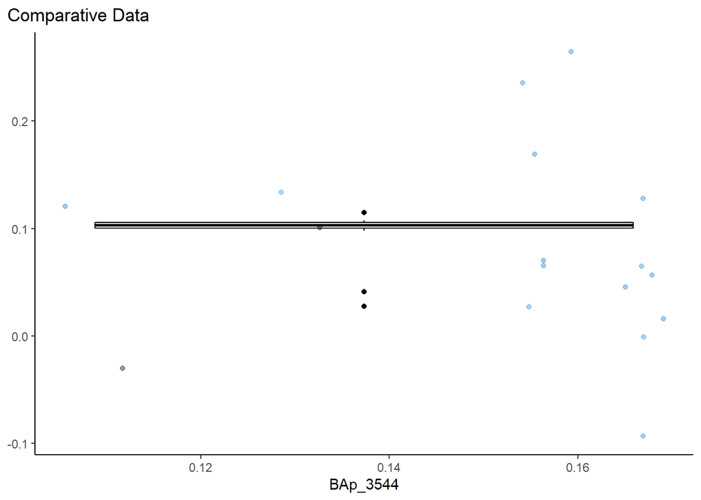

```r
Rainfall_graph_for_marriage_and_divorce <- cbind_BAp_3544_Compar_Data %>%
  drop_na(c(Marriage_BAp_3544:Divorce_BAp_3544)) %>%
  ggplot +
  aes(
    x = Marriage_BAp_3544,
    y = Divorce_BAp_3544,
    fill = Divorce_BAp_3544,
    color = Divorce_BAp_3544
  ) +
  geom_jitter(
    alpha = .5,
    height = .2,
    width = .0,
    na.rm = TRUE
  ) +
  geom_boxplot(
    width = .1,
    color = "Black",
    fill = "transparent"
  ) +
  ggdist::stat_sample_slabinterval(
    alpha = .5,
    height = .2,
    color = "black",
    position = position_nudge(y = .2)
  ) +
  theme_classic() +
  labs(title = "Comparative Data",
       y = NULL,
       x = "BAp_3544"
       ) +
  theme(plot.title.position = "plot") +
  guides(color = guide_none(), fill = guide_none())
Rainfall_graph_for_marriage_and_divorce
```

```r
ggsave(here::here("Final_project", "output", "figure",
                  "Rainfall_graph_for_marriage_and_divorce.svg"),
       Rainfall_graph_for_marriage_and_divorce,
       height = 6,
       width = 6)
```

Oh god. This is an abomination. Okay, nothing to see here. Let’s go back to regular graph.